# TFM 1

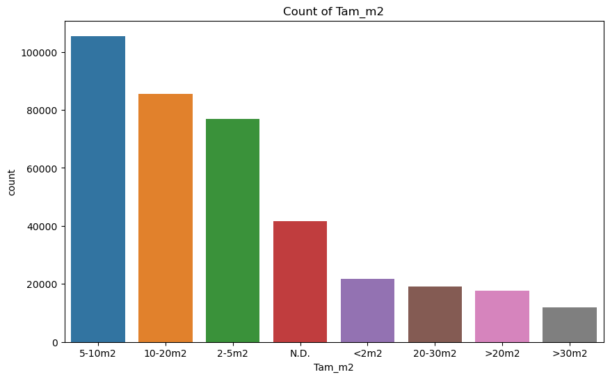

```python
#Realizamos la visualización para Tam_m2 de df_all_tables.

plt.figure(figsize=(10, 6))
sns.countplot(x='Tam_m2', data=df_all_tables, order=df_all_tables['Tam_m2'].value_counts().index)
plt.xticks(rotation=0)
plt.title('Count of Tam_m2')
plt.show()
```

Vemos que la mayoría de valores están entre los 2-5m, 5-10 y 10-20. Esto nos indica que el tamaño de estos establecimientos suele ser medio.

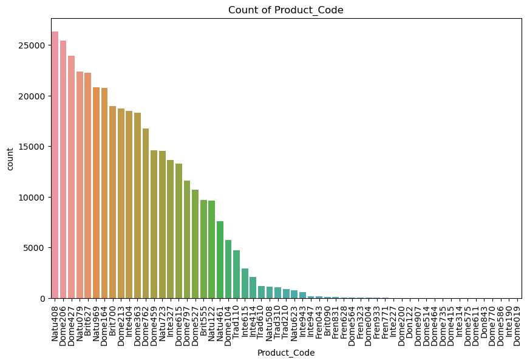

```python
#Realizamos la visualización para los códigos de producto de df_all_tables.
plt.figure(figsize=(10, 6))
sns.countplot(x='Product_Code', data=df_all_tables, order=df_all_tables['Product_Code'].value_counts().index)
plt.xticks(rotation=90)
plt.title('Count of Product_Code')
plt.show()
```

Hay algo muy interesante y es que para la mitad de productos casi no hay registros, no hay ventas o deliveries por ejemplo. Esto hace plantear la necesidad de tener esos productos disponibles tanto como para analizar sus datos como para realmente tenerlos en venta.

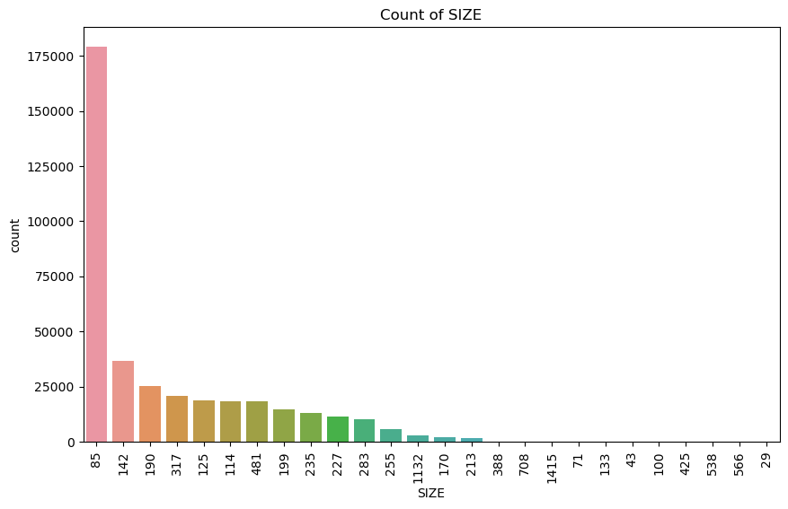

```python
#Realizamos la visualización para SIZE de df_all_tables.

plt.figure(figsize=(10, 6))
sns.countplot(x='SIZE', data=df_all_tables, order=df_all_tables['SIZE'].value_counts().index)
plt.xticks(rotation=90)
plt.title('Count of SIZE')
plt.show()
```

Hay una Size (85) que acapara gran parte de los registros y que casi la mitad de Size no tienen registros, por lo que también seria posible dejar de trabajar con ellos.

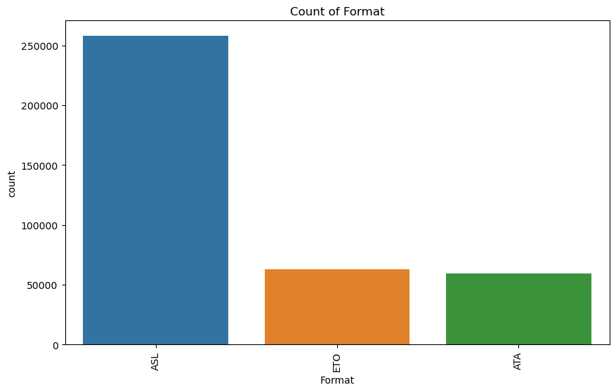

```python
#Realizamos la visualización para Format de df_all_tables.

plt.figure(figsize=(10, 6))
sns.countplot(x='Format', data=df_all_tables, order=df_all_tables['Format'].value_counts().index)
plt.xticks(rotation=90)
plt.title('Count of Format')
plt.show()
```

El Format predominante es ASL, muy por debajo están ETO y ATA.

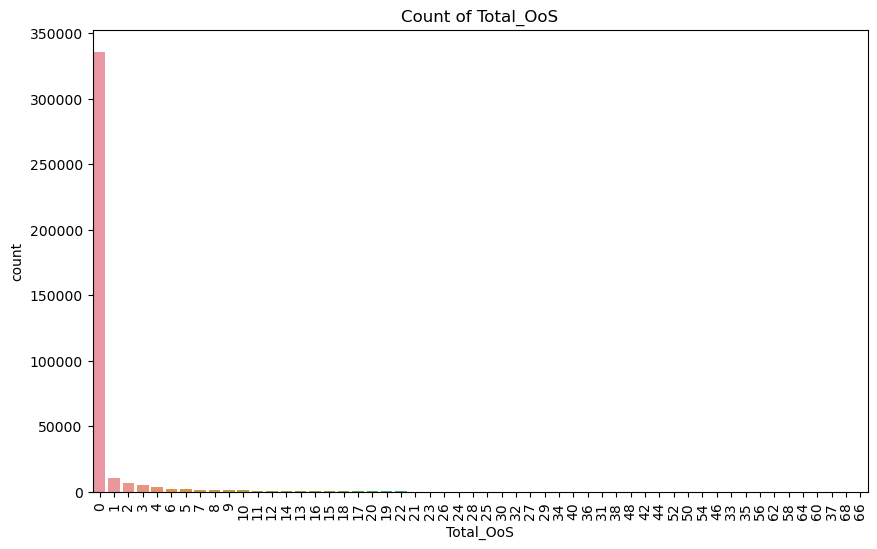

```python
#Además, aunque no se trata de un campo categórico, realizamos la revisión de los registros que aparecen con rotura de stock.

plt.figure(figsize=(10, 6))
sns.countplot(x='Total_OoS', data=df_all_tables, order=df_all_tables['Total_OoS'].value_counts().index)
plt.xticks(rotation=90)
plt.title('Count of Total_OoS')
plt.show()
```

Vemos que hay muchísimos más registros sin rotura que con ella, por lo que no parece que la rotura de stock sea un gran problema a priori. Sin embargo es interesante estudiarla, ya que la rotura de stock supone menos ventas y por tanto menos ingresos. El hecho de que la mayoría de valores sean 0 pueden también condicionar el entrenamiento de modelos de predicción, ya que el peso de ese valor será mayor.

#### df_Delivery_Route

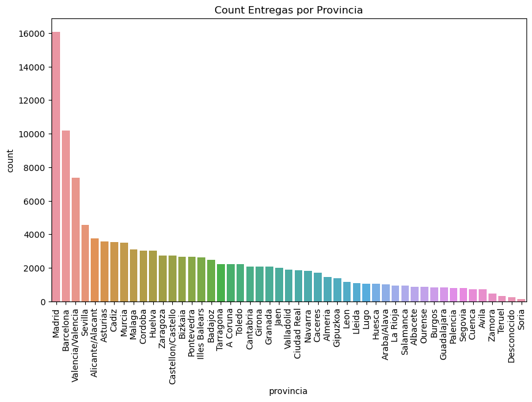

```python
#Realizamos un ejercicio similar para los campos categóricos de df_Delivery_Route

#Hacemos visualización de Count por provincia:
plt.figure(figsize=(10, 6))
sns.countplot(x='provincia', data=df_Delivery_Route, order=df_Delivery_Route['provincia'].value_counts().index)
plt.xticks(rotation=90)
plt.title('Count Entregas por Provincia')
plt.show()
```

Podemos apreciar que la mayoría del peso de Delivery por provincia se queda en Madrid, seguido por Barcelona y Valencia, que son ciudades más grandes. Hay diferencia de los valores más grandes de esta tabla y la que indica solo meses (df_all_tables), entre Madrid y el resto de provincias.

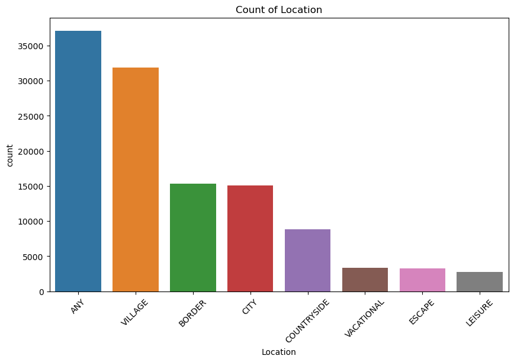

```python
#Hacmeos el mismo ejercicio para "Location"
plt.figure(figsize=(10, 6))
sns.countplot(x='Location', data=df_Delivery_Route, order=df_Delivery_Route['Location'].value_counts().index)
plt.xticks(rotation=45)
plt.title('Count of Location')
plt.show()
```

En este caso gran parte se queda en "Any" y "Village". La distribución de registros es similar a los de df_all_tables.

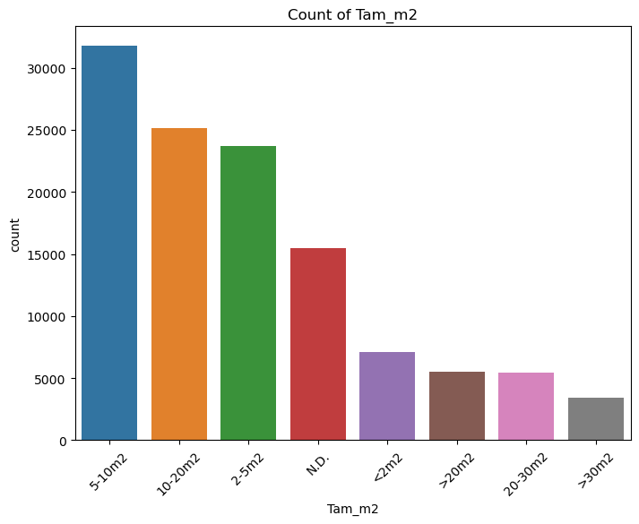

```python
#Tam_m2 de df_Delivery_Route

plt.figure(figsize=(8, 6))
sns.countplot(x='Tam_m2', data=df_Delivery_Route, order=df_Delivery_Route['Tam_m2'].value_counts().index)
plt.xticks(rotation=45)
plt.title('Count of Tam_m2')
plt.show()
```

La distribución de valores es muy similar a la tabla df_all_tables

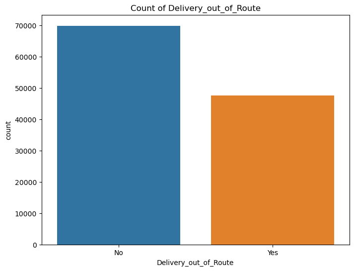

```python
#Revisamos Count Delivery_out_of_Route:

plt.figure(figsize=(8, 6))
sns.countplot(x='Delivery_out_of_Route', data=df_Delivery_Route, order=df_Delivery_Route['Delivery_out_of_Route'].value_counts().index)
plt.xticks(rotation=0)
plt.title('Count of Delivery_out_of_Route')
plt.show()
```

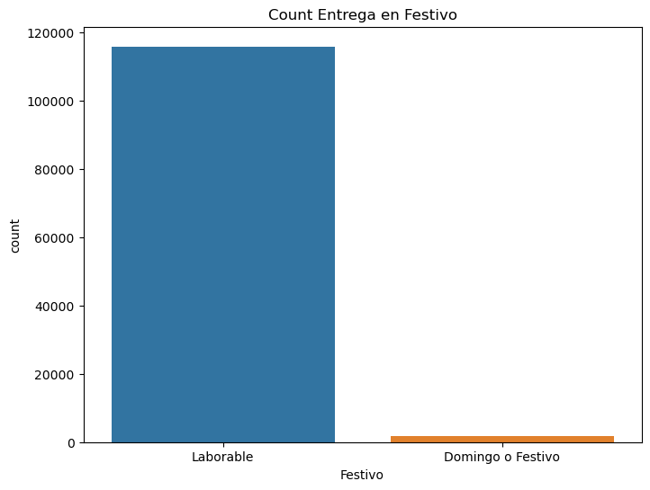

```python
#Para df_Delivery_Route revisamos también el
#campo Festivo que nos va a indicar si se han hecho entregas en días festivos/domingos o no.

plt.figure(figsize=(8, 6))
sns.countplot(x='Festivo', data=df_Delivery_Route, order=df_Delivery_Route['Festivo'].value_counts().index)
plt.xticks(rotation=0)
plt.title('Count Entrega en Festivo')
plt.show()
```

Vemos que la gran mayoría de entregas han sido el días laborables.

#### df_Sales_Rotura

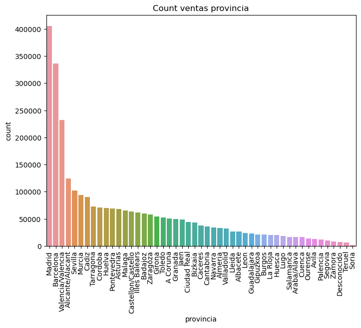

```python
#Ahora revisaremos el dataframe df_Sales_Rotura.

plt.figure(figsize=(8, 6))
sns.countplot(x='provincia', data=df_Sales_Rotura, order=df_Sales_Rotura['provincia'].value_counts().index)
plt.xticks(rotation=90)
plt.title('Count ventas provincia')
plt.show()
```

Vemos que la distribución de valores es similar a los otros dataframes

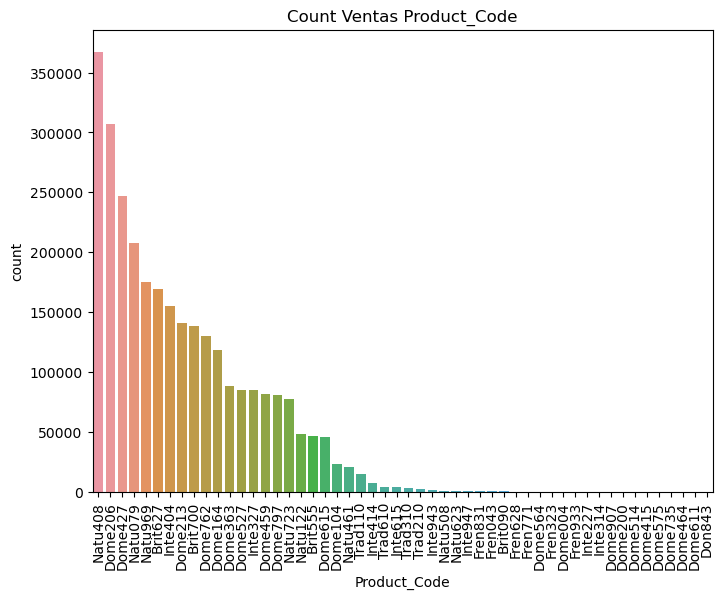

```python
#Revisaremos el count de Sales por Product_Code.
plt.figure(figsize=(8, 6))
sns.countplot(x='Product_Code', data=df_Sales_Rotura, order=df_Sales_Rotura['Product_Code'].value_counts().index)
plt.xticks(rotation=90)
plt.title('Count Ventas Product_Code')
plt.show()
```

Aquí tenemos valores por días.En este caso el orden de ventas es similar, pero la diferencia entre productos es más acentuado que en la tabla df_all_tables donde se estudiaban los valores por meses.

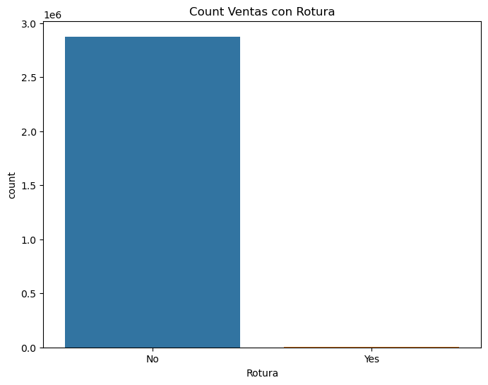

```python
#Revisaremos el campo Rotura que nos indica si se ha producido problemas de stock a la vez que ventas,
#lo que puede indicar que se hayan limitado esas ventas.

plt.figure(figsize=(8, 6))
sns.countplot(x='Rotura', data=df_Sales_Rotura, order=df_Sales_Rotura['Rotura'].value_counts().index)
plt.xticks(rotation=0)
plt.title('Count Ventas con Rotura')
plt.show()
```

Vemos que los problemas de rotura parecen ser bajos.

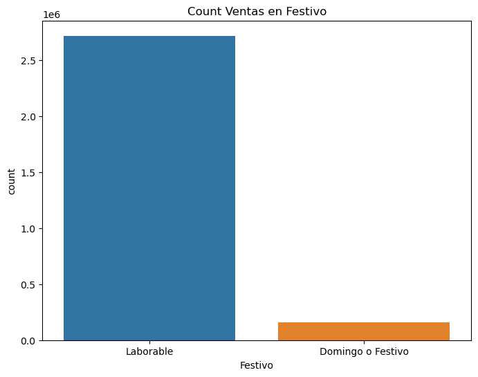

```python
#Revisamos el campo "Festivo" para comprobar si se han dado ventas en días festivos o domingos,
#ya que estos establecimientos abren en teoría solo 6 días a la semana,
#lo que supondría que al menos los domingos no debería haber ventas.

plt.figure(figsize=(8, 6))
sns.countplot(x='Festivo', data=df_Sales_Rotura, order=df_Sales_Rotura['Festivo'].value_counts().index)
plt.xticks(rotation=0)
plt.title('Count Ventas en Festivo')
plt.show()
```

Aunque hay pocos valores, sí que se dan casos de ventas en festivos/domingos. Esto se puede deber por un lado a que los campos de festivos no sean correctos, pero al revisar con sql se han visto ventas en días que caían en domingo.

Por ejemplo para asegurarnos podemos buscar algun domingo o festivo y revisar si hay ventas.

```python
#Vemos que varios de los resultados que se obtienen son para el 2015-08-30, que fue domingo.

df_Sales_Rotura[(df_Sales_Rotura['Festivo'] == 'Domingo o Festivo') & (df_Sales_Rotura['Sales_DAY'] == '2015-08-30')]
```

|  | Sales_DAY | Affiliated_Code | POSTALCODE | poblacion | provincia | Product_Code | Sales_Uds | OoS_DAY | Rotura | Festivo |
| --- | --- | --- | --- | --- | --- | --- | --- | --- | --- | --- |
| 2141 | 2015-08-30 | WkGFAA1 | 7007 | Palma De Mallorca | Illes Balears | Trad310 | 2 | NaT | No | Domingo o Festivo |
| 2225 | 2015-08-30 | XCe7AAH | 28300 | Aranjuez | Madrid | Inte327 | 2 | NaT | No | Domingo o Festivo |
| 2451 | 2015-08-30 | WuLdAAL | 43883 | Barquera, La | Tarragona | Brit555 | 1 | NaT | No | Domingo o Festivo |
| 3035 | 2015-08-30 | WUmwAAH | 8788 | Vilanova Del Cami | Barcelona | Inte327 | 5 | NaT | No | Domingo o Festivo |
| 3213 | 2015-08-30 | WswVAAT | 39618 | Pontejos | Cantabria | Dome206 | 1 | NaT | No | Domingo o Festivo |
| ... | ... | ... | ... | ... | ... | ... | ... | ... | ... | ... |
| 1913554 | 2015-08-30 | WsK2AAL | 15141 | Oseiro (arteixo) | A Coruna | Dome206 | 1 | NaT | No | Domingo o Festivo |
| 1921586 | 2015-08-30 | WU2aAAH | 30868 | Alamillo | Murcia | Natu408 | 3 | NaT | No | Domingo o Festivo |
| 1923556 | 2015-08-30 | WTdQAAX | 18009 | Granada | Granada | Natu408 | 5 | NaT | No | Domingo o Festivo |
| 1932076 | 2015-08-30 | WlM4AAL | 3699 | Alcoraya, La | Alicante/Alacant | Dome206 | 4 | NaT | No | Domingo o Festivo |
| 1935994 | 2015-08-30 | X8atAAD | 8027 | Barcelona | Barcelona | Natu969 | 2 | NaT | No | Domingo o Festivo |

3632 rows × 10 columns

# ANÁLISIS UNIVARIANTE:

```
array([[<Axes: title={'center': 'Cost_price'}>,
        <Axes: title={'center': 'Sell_price'}>],
       [<Axes: title={'center': 'Margin'}>, <Axes: >]], dtype=object)
```

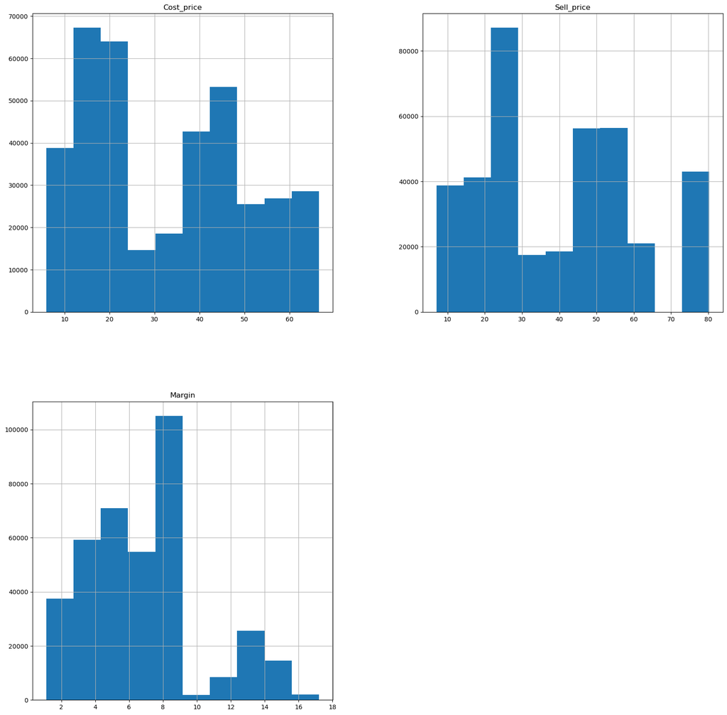

```python
#Análizamos los valores numéricos para df_all_tables.
df_all_tables[['Cost_price','Sell_price','Margin']].hist(figsize=(20, 20))
```

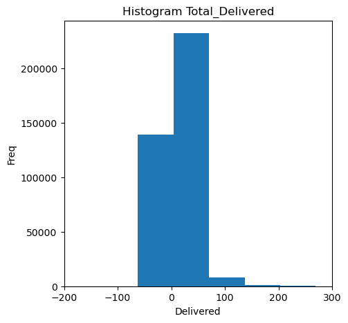

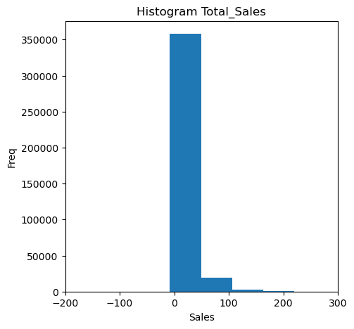

```python
#Hacemos visualización a parte de Total_Delivered y Total_Sales para ver mejor su detalle:

plt.figure(figsize=(5, 5))
plt.hist(df_all_tables['Total_Delivered'], bins=20)
plt.xlim(-200, 300)
plt.xlabel('Delivered')
plt.ylabel('Freq')
plt.title('Histogram Total_Delivered')
plt.show()

plt.figure(figsize=(5, 5))
plt.hist(df_all_tables['Total_Sales'], bins=20)
plt.xlim(-200, 300)
plt.xlabel('Sales')
plt.ylabel('Freq')
plt.title('Histogram Total_Sales')
plt.show()
```

En Cost_Price tenemos valores que van desde 5 a menos de 70, con picos alrededor tanto de 15 como 45. Podría deberse por ejemplo a una agrupación de tipos de producto en torno a dos grupos de precio.

En Sell_Price son valores similares pero un poco más altos, hasta 80 con picos en 20 y 50 aprox. Pasa algo similar a Cost_Price, ya que los Sell_Price se han creado a partir de Cost_Price.

El márgen es más alto en 8 y en 13, y llega a un máximo de 17. No tenemos valores negativos, por lo que no se han vendido productos por un precio menor que su coste.

Para Total_Sales hay aun valores negativos aunque menos y el máximo supera 200.

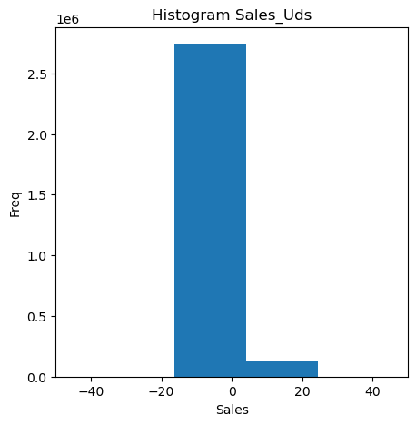

```python
# df_Delivery_Route no tiene valores numéricos a valorar, son categóricos.

#Podemos revisar las uds diarias vendidas de la tabla df_Sales_Rotura:

plt.figure(figsize=(5, 5))
plt.hist(df_Sales_Rotura['Sales_Uds'], bins=20)
plt.xlim(-50, 50)
plt.xlabel('Sales')
plt.ylabel('Freq')
plt.title('Histogram Sales_Uds')
plt.show()
```

# ANÁLISIS DE CORRELACIÓN:

Este análisis es también parte de EDA y nos permite ver cómo se relacionan los diferentes campos entre ellos, cómo son de dependientes. Los valores van de -1 a 1. 1 indica una fuerte relación positiva entre variables,0 indica que no hay relación y -1 que hay relación negativa entre las dos variables

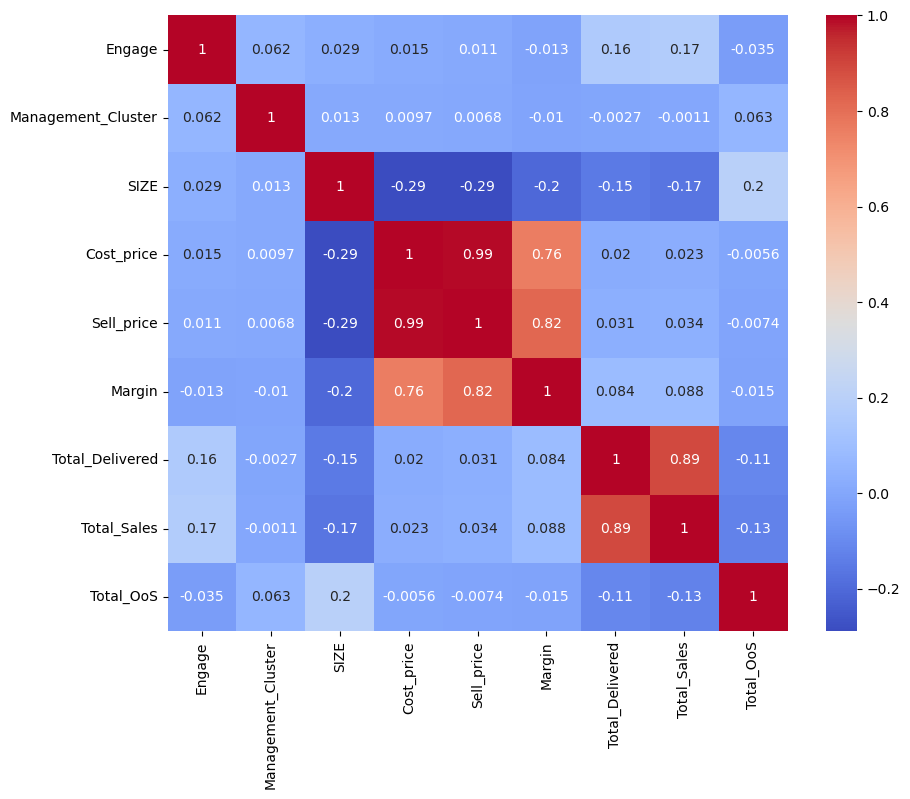

```python
#Para df_all_tables seleccionaremos las variables numéricas más importantes:

correlation_matrix_1 = df_all_tables[['Engage','Management_Cluster'
                                      ,'SIZE', 'Cost_price','Sell_price','Margin',
                                      'Total_Delivered','Total_Sales', 'Total_OoS' ]].corr()

plt.figure(figsize=(10, 8))
sns.heatmap(correlation_matrix_1, annot=True, cmap='coolwarm')
plt.show()
```

En este caso lo más obvio son las relaciones entre Cost_price, Sell_price,Margin y entre Total_Delivered y Total_Sales. Esto implica una relación cercana a 1 entre estas variables. Esto nos indica que a un mayor Sell_price también se da un mayor Cost_price, a mayor Margin mayor Sell_Price, etc. Tal vez no sea necesario incluir en un mismo estudio por ejemplo Sell_Price y Cost_Price.

Además hay relaciones negativas entre Size y Cost_price, Sell_price,Margin,Total_Delivered y Total_Sales,lo que implica que esas variables bajan con el aumento de Size.

Total_OoS por otro lado no tiene una relación fuerte con ninguna otra variable.

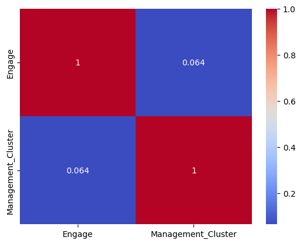

```python
#En el caso de df_Delivery_Route solo hay 2 columnas que se pueden valorar, Engage y Management Cluster
correlation_matrix_2 = df_Delivery_Route[['Engage','Management_Cluster']].corr()
sns.heatmap(correlation_matrix_2, annot=True, cmap='coolwarm')
plt.show()
```

Vemos que la relación es cercana a 0 lo que indica que a nivel de este df, que valora las entregas, no hay casi relación entre Engage y Management_Cluster

Para df_Sales_Rotura solo hay 1 variable numérica (Sales_Uds), por lo que no vamos a poder hacer una correlation matrix.